# day5_SCHMITZ.R

laura

2025-12-01

# Analyzing the dataset **GSE13005**

### *Macrophage response to silica nanoparticles in mice*

**`Setup`**

**`Loading packages`**

```r
library(tidyverse)
```

```r
library(pheatmap)
library(gemma.R)
library(limma)
library(patchwork)
library(ComplexHeatmap)
```

[output not shown]

```r
library(msigdbr)
library(gemma.R)
```

**Getting metadata and expression data from Gemma**

```r
metadata <- get_dataset_samples("GSE13005") |>
  make_design('text') |>
  select(-factorValues)
head(metadata)
```

```
##                                                                                                                treatment
## 500nm silica at high dose, rep3 silicon dioxide nanoparticle with 500 nm silica particles and delivered at dose 50 ug/mL
## 500nm silica at high dose, rep2 silicon dioxide nanoparticle with 500 nm silica particles and delivered at dose 50 ug/mL
## 500nm silica at high dose, rep1 silicon dioxide nanoparticle with 500 nm silica particles and delivered at dose 50 ug/mL
## 500nm silica at mid dose, rep3  silicon dioxide nanoparticle with 500 nm silica particles and delivered at dose 20 ug/mL
## 500nm silica at mid dose, rep2  silicon dioxide nanoparticle with 500 nm silica particles and delivered at dose 20 ug/mL
## 500nm silica at mid dose, rep1  silicon dioxide nanoparticle with 500 nm silica particles and delivered at dose 20 ug/mL
##                                            block
## 500nm silica at high dose, rep3 Batch_03_9/20/06
## 500nm silica at high dose, rep2 Batch_02_9/13/06
## 500nm silica at high dose, rep1 Batch_01_8/30/06
## 500nm silica at mid dose, rep3  Batch_03_9/20/06
## 500nm silica at mid dose, rep2  Batch_02_9/13/06
## 500nm silica at mid dose, rep1  Batch_01_8/30/06
```

```r
with(metadata, table(treatment, block))
```

```
##                                                                                           block
## treatment                                                                                  Batch_01_8/30/06
##   reference substance role                                                                                1
##   silicon dioxide nanoparticle delivered at dose 5 ug/mL                                                  1
##   silicon dioxide nanoparticle with 10 nm silica particles and delivered at dose 20 ug/mL                 1
##   silicon dioxide nanoparticle with 10 nm silica particles and delivered at dose 50 ug/mL                 1
##   silicon dioxide nanoparticle with 500 nm silica particle and delivered at dose 5 ug/mL                  1
##   silicon dioxide nanoparticle with 500 nm silica particles and delivered at dose 20 ug/mL                1
##   silicon dioxide nanoparticle with 500 nm silica particles and delivered at dose 50 ug/mL                1
##                                                                                           block
## treatment                                                                                  Batch_02_9/13/06
##   reference substance role                                                                                2
##   silicon dioxide nanoparticle delivered at dose 5 ug/mL                                                  1
##   silicon dioxide nanoparticle with 10 nm silica particles and delivered at dose 20 ug/mL                 1
##   silicon dioxide nanoparticle with 10 nm silica particles and delivered at dose 50 ug/mL                 1
##   silicon dioxide nanoparticle with 500 nm silica particle and delivered at dose 5 ug/mL                  1
##   silicon dioxide nanoparticle with 500 nm silica particles and delivered at dose 20 ug/mL                1
##   silicon dioxide nanoparticle with 500 nm silica particles and delivered at dose 50 ug/mL                1
##                                                                                           block
## treatment                                                                                  Batch_03_9/20/06
##   reference substance role                                                                                0
##   silicon dioxide nanoparticle delivered at dose 5 ug/mL                                                  1
##   silicon dioxide nanoparticle with 10 nm silica particles and delivered at dose 20 ug/mL                 1
##   silicon dioxide nanoparticle with 10 nm silica particles and delivered at dose 50 ug/mL                 1
##   silicon dioxide nanoparticle with 500 nm silica particle and delivered at dose 5 ug/mL                  1
##   silicon dioxide nanoparticle with 500 nm silica particles and delivered at dose 20 ug/mL                1
##   silicon dioxide nanoparticle with 500 nm silica particles and delivered at dose 50 ug/mL                1
```

```r
expression_data <- get_dataset_processed_expression("GSE13005")
expression_data <- as.data.frame(expression_data)
stopifnot(all(row.names(metadata) %in% colnames(expression_data)))
```

**5.1) How many samples do you have? What are the conditions? Will you filter the dataset and focus on a subset of data?**

I have 21 samples

```r
dim(metadata)
```

```
## [1] 21  2
```

The conditions refer to stimulation of mice macrophages with silicon dioxide nanoparticles conjugated with silica particles at different sizes and amounts:

```r
metadata_summary <- metadata %>%
  group_by(treatment) %>%   # group by unique combinations
  summarise(count = n(), .groups = "drop")  # count occurrences

metadata_summary
```

```
## # A tibble: 7 × 2
##   treatment                                                                count
##   <chr>                                                                    <int>
## 1 reference substance role                                                     3
## 2 silicon dioxide nanoparticle delivered at dose 5 ug/mL                       3
## 3 silicon dioxide nanoparticle with 10 nm silica particles and delivered …     3
## 4 silicon dioxide nanoparticle with 10 nm silica particles and delivered …     3
## 5 silicon dioxide nanoparticle with 500 nm silica particle and delivered …     3
## 6 silicon dioxide nanoparticle with 500 nm silica particles and delivered…     3
## 7 silicon dioxide nanoparticle with 500 nm silica particles and delivered…     3
```

I will filter the expression data to exclude all entries lacking any genes

```r
expression_data <- subset(expression_data, !is.na(GeneSymbol) & GeneSymbol != "")
stopifnot(all(row.names(metadata) %in% colnames(expression_data)))
```

Now I have the expression data for **13145 genes** upon **6 different treatment conditions**

```r
length(unique(expression_data$GeneSymbol))
```

```
## [1] 13145
```

**5.2) Plot correlation heatmaps and MDS plots. Discuss the signal to noise ratio.**

### **Correlation heatmap**

Making expression_data as a matrix:

```r
data_matrix <- as.matrix(expression_data[,row.names(metadata)])
row.names(data_matrix) <- expression_data$GeneSymbol
```

Plotting the heatmap:

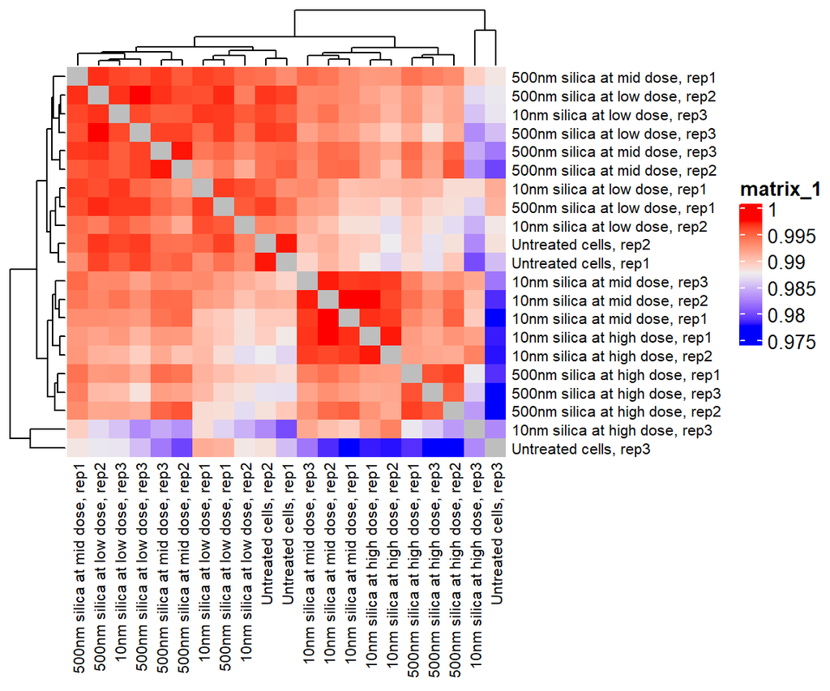

```r
correlation_heatmap <- cor(data_matrix, method = "spearman")
diag(correlation_heatmap) <- NA # removes the diagonal
Heatmap(correlation_heatmap,
        row_names_gp = gpar(fontsize = 8),
        column_names_gp = gpar(fontsize = 8))
```

### **MDS projection**

Changing the treatment names for better readability in the graph:

```r
metadata_simplified <- metadata %>%
  mutate(treatment = treatment %>%
           # Replace "silicon dioxide nanoparticle" with "SiO2"
           str_replace_all("silicon dioxide nanoparticle", "SiO2 NPs") %>%
           # Extract particle size (e.g., "500 nm") and keep it
           str_replace_all("with (\\d+) nm silica particles", "+ \\1nm silica particles") %>%
           # Extract dose (e.g., "delivered at dose 50 ug/mL") and shorten it
           str_replace_all("delivered at dose (\\d+) ug/mL", "\\1µg/mL") %>%
           # Remove unnecessary words like "and"
           str_replace_all(" and ", ", ")
  )
```

Plotting the MDS plot:

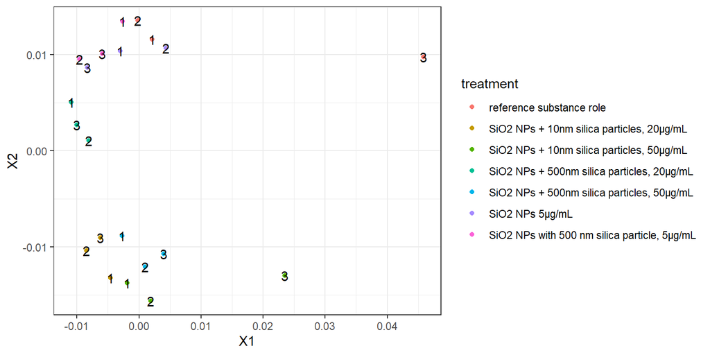

```r
data.frame(cmdscale(dist(2-correlation_heatmap),eig=TRUE, k=2)$points) |>
  add_column(treatment = metadata_simplified$treatment) |>
  rownames_to_column("sample") |>
  mutate(replicate = str_extract(sample, "\\d+$")) |>
  ggplot(aes(x=X1,y=X2)) +
  geom_point(aes(color=treatment)) +
  geom_text(aes(label=replicate)) +
  theme_bw()
```

**5.3) Report your model matrix (heatmap) and describe each coefficient in terms of which conditions is going to compare.**

**`Setting up the model matrix`**

```r
metadata_simplified <- metadata_simplified |>
  mutate(treatment = as.factor(treatment)) |>
  mutate(treatment = relevel(treatment, ref = "reference substance role"))
levels(metadata_simplified$treatment)
```

```
## [1] "reference substance role"
## [2] "SiO2 NPs + 10nm silica particles, 20µg/mL"
## [3] "SiO2 NPs + 10nm silica particles, 50µg/mL"
## [4] "SiO2 NPs + 500nm silica particles, 20µg/mL"
## [5] "SiO2 NPs + 500nm silica particles, 50µg/mL"
## [6] "SiO2 NPs 5µg/mL"
## [7] "SiO2 NPs with 500 nm silica particle, 5µg/mL"
```

```r
model_matrix <- model.matrix(~ treatment, data = metadata_simplified)
colnames(model_matrix) <- sub("^treatment", "", colnames(model_matrix))
```

**Intercept** corresponds to **untreated cells treated with a reference substance** control and **treatments** corresponds to all treatment conditions, i.e. **SiO2 nanoparticles** conjugated to **10nM** or **500nm** silica particles at **50µg/mL**, **20µg/mL**, or **5µg/mL**.

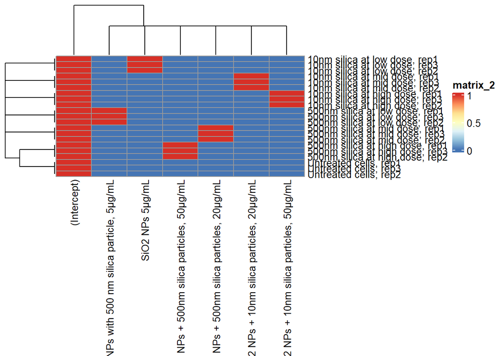

```r
pheatmap(model_matrix)
```

**5.4) Provide your volcano plot and p-value distribution. Do you see significant differences? In which conditions (if you have many). How many significant genes do you find?**

**Data normalization and differential expression**

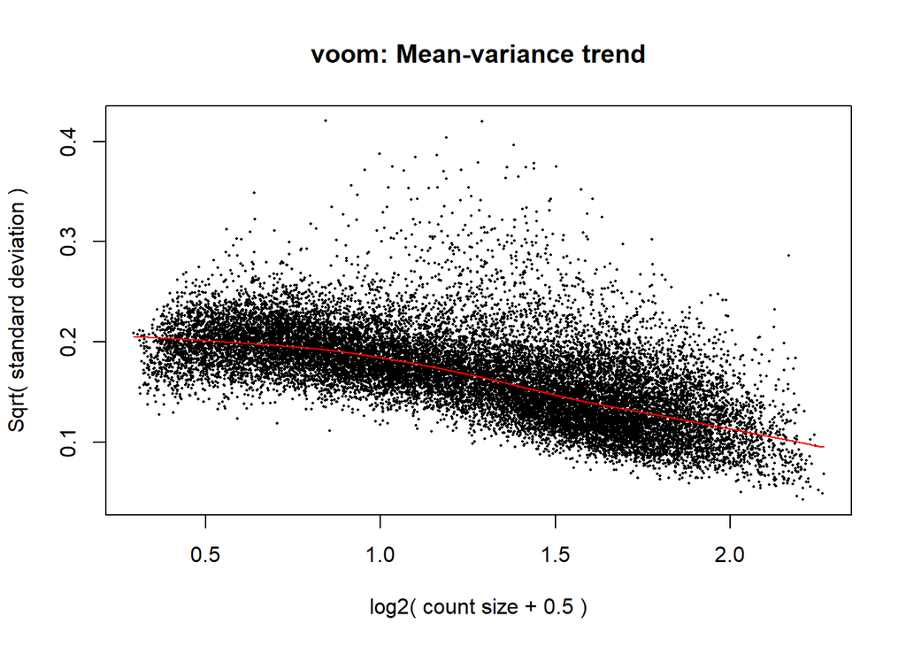

```r
dataVoom <- voom(data_matrix, design=model_matrix, plot = TRUE)
```

```r
limmaFit <- lmFit(dataVoom, design=model_matrix)
limmaFit <- eBayes(limmaFit)
limmaRes <- list()
for(coefx in colnames(coef(limmaFit))){
  print(coefx)
  limmaRes[[coefx]] <- topTable(limmaFit, coef=coefx,number = Inf) |>
    rownames_to_column("gene")
}
```

```
## [1] "(Intercept)"
## [1] "SiO2 NPs + 10nm silica particles, 20µg/mL"
## [1] "SiO2 NPs + 10nm silica particles, 50µg/mL"
## [1] "SiO2 NPs + 500nm silica particles, 20µg/mL"
## [1] "SiO2 NPs + 500nm silica particles, 50µg/mL"
## [1] "SiO2 NPs 5µg/mL"
## [1] "SiO2 NPs with 500 nm silica particle, 5µg/mL"
```

```r
limmaRes <- bind_rows(limmaRes, .id = "coef")
limmaRes <- filter(limmaRes, coef != "(Intercept)")
```

As indicated by the **P-value distribution**, all genes are highly expressed (minimum AveExpr of 4.9) with no outliers, thus no need for filtering.

### **Volcano plot:**

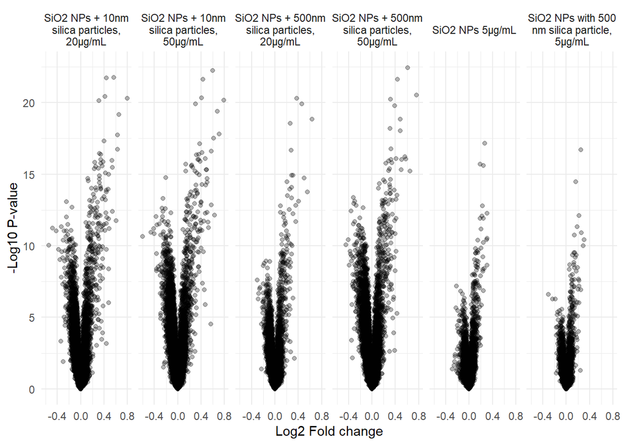

```r
ggplot(
  data = limmaRes,
  mapping = aes(x = logFC, y = -log10(P.Value))
) +
  geom_point(alpha = 0.3) +
  theme_minimal() +
  facet_grid(
    ~coef,
    labeller = labeller(coef = function(x) str_wrap(x, width = 20))
  ) +
  labs(
    x = "Log2 Fold change",
    y = "-Log10 P-value"
  )
```

### **P-value distribution**

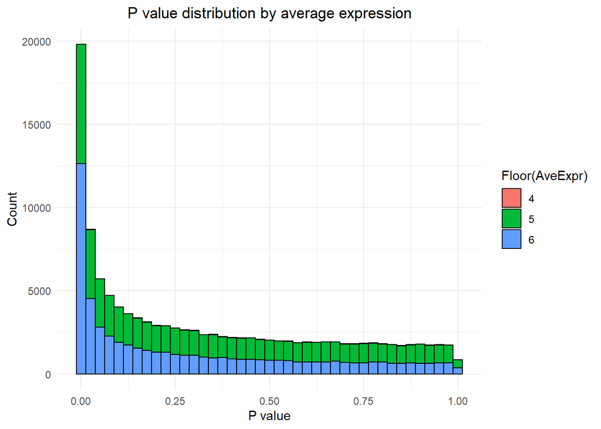

```r
ggplot(limmaRes,
       aes(x = P.Value, fill = factor(floor(AveExpr)))) +
  geom_histogram(binwidth = 0.025, color = "#000000")  +
  theme_minimal() +
  labs(
    title = "P value distribution by average expression",
    x = "P value",
    y = "Count",
    fill = "Floor(AveExpr)") +
  theme(
    plot.title = element_text(hjust = 0.5)  # center the title
  )
```

In this dataset, **17763** entries corresponding to **6752** significant genes (out of 13145) are found

```r
limmaRes %>%
  summarise(unique_IDs = n_distinct(ID))
```

```
##   unique_IDs
## 1      13145
```

```r
limmaResSig <- limmaRes |> filter(adj.P.Val <= 0.05)
limmaResSig %>% count()
```

```
##       n
## 1 17763
```

```r
limmaResSig %>% summarise(unique_IDs = n_distinct(ID))
```

```
##   unique_IDs
## 1       6752
```

**5.5) Plot the (normalized) data for one and more significant genes and discuss whether the differences in the data fit to the statistics (log fold change and p-value) returned by Limma.**

Top 10 significant genes:

```r
top10 <- limmaResSig %>% group_by(ID) %>% summarise(max_logFC = max(logFC), .groups = "drop") %>% slice_max(order_by = max_logFC, n = 10)
print(top10)
```

```
## # A tibble: 10 × 2
##    ID       max_logFC
##    <chr>        <dbl>
##  1 Rhob         0.799
##  2 Cxcl2        0.760
##  3 Nr4a2        0.706
##  4 Gdf15        0.654
##  5 Ccl2         0.631
##  6 Klf2         0.631
##  7 Dusp1        0.608
##  8 Plk2         0.578
##  9 Serpine1     0.577
## 10 Klf3         0.570
```

**Visualizing one gene:**

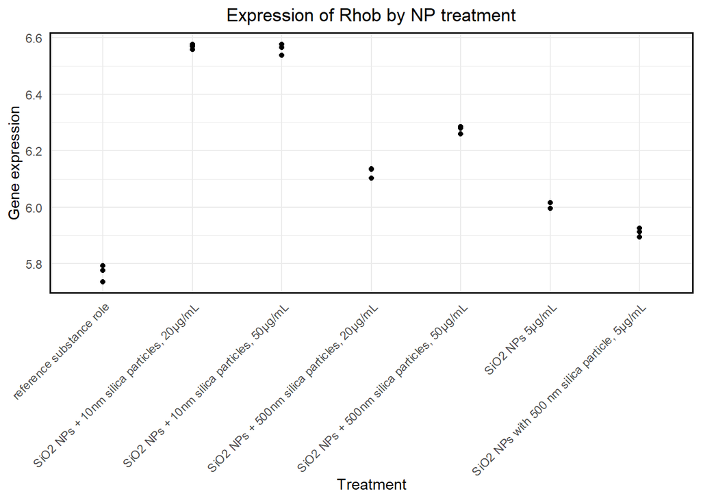

```r
plot_top1 <- metadata_simplified |> mutate(Expression_Rhob=dataVoom$E["Rhob", ])

ggplot(plot_top1,
       aes(x = treatment,
           y = Expression_Rhob)) +
  geom_point() +
  theme_minimal() +
  labs(
    title = "Expression of Rhob by NP treatment",
    x = "Treatment",
    y = "Gene expression"
  ) +
  theme(
    plot.title = element_text(hjust = 0.5),        # center the title
    panel.border = element_rect(color = "black",
                                fill = NA, size = 1),  # black border
    axis.text.x = element_text(angle = 45, hjust = 1)  # diagonal x labels
  )
```

The plot shows highest **Rhob** expression for **10nm particles** at both **high and mid dose**, and lowest expression for control (reference substance role) and low dose 500nm nanoparticles. This goes along with the logFC calculated for these stimuli (the most positive logFC = the highest expression in comparison to the reference)

```r
limmaRes %>%
  filter(ID == "Rhob") %>%
  select(coef, logFC) %>%
  arrange(desc(logFC))
```

```
##                                           coef     logFC
## 1    SiO2 NPs + 10nm silica particles, 20µg/mL 0.7994939
## 2    SiO2 NPs + 10nm silica particles, 50µg/mL 0.7907052
## 3   SiO2 NPs + 500nm silica particles, 50µg/mL 0.5056704
## 4   SiO2 NPs + 500nm silica particles, 20µg/mL 0.3550094
## 5                              SiO2 NPs 5µg/mL 0.2330642
## 6 SiO2 NPs with 500 nm silica particle, 5µg/mL 0.1417568
```

**Visualizing multiple genes:**

**`Plotting statistical results`**

```r
goi.all <- limmaResSig %>% group_by(coef) %>% slice_max(order_by = logFC, n = 5) %>% pull(ID)
print(goi.all)
```

```
##  [1] "Rhob"  "Cxcl2" "Klf2"  "Nr4a2" "Ccl2"  "Rhob"  "Nr4a2" "Cxcl2" "Ccl2"
## [10] "Klf2"  "Cxcl2" "Gdf15" "Plk2"  "Dusp1" "Maff"  "Cxcl2" "Gdf15" "Dusp1"
## [19] "Plk2"  "Maff"  "Plk2"  "Cxcl2" "Hbegf" "Maff"  "Atf3"  "Cxcr4" "Plk2"
## [28] "Cxcl2" "Atf3"  "Gdf15"
```

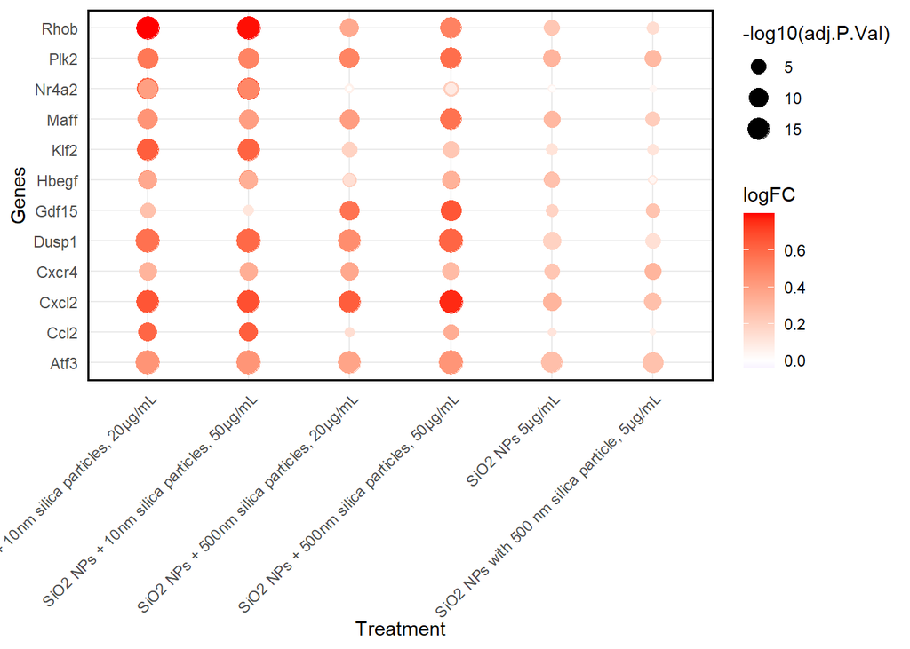

```r
(p.coef <- limmaRes %>%
    filter(ID %in% goi.all) %>%
    ggplot(aes(y=ID, x=str_remove(coef, "treatment"), color=logFC, size=-log10(adj.P.Val))) +
    geom_point() +
    scale_color_gradient2(high="red", low="blue") +
    theme_minimal() +
    labs(
      x = "Treatment",
      y = "Genes"
    ) +
    theme(
      plot.title = element_text(hjust = 0.5),        # center the title
      panel.border = element_rect(color = "black",
                                  fill = NA, size = 1),  # black border
      axis.text.x = element_text(angle = 45, hjust = 1)  # diagonal x labels
    ))
```

**`Plotting expression data`**

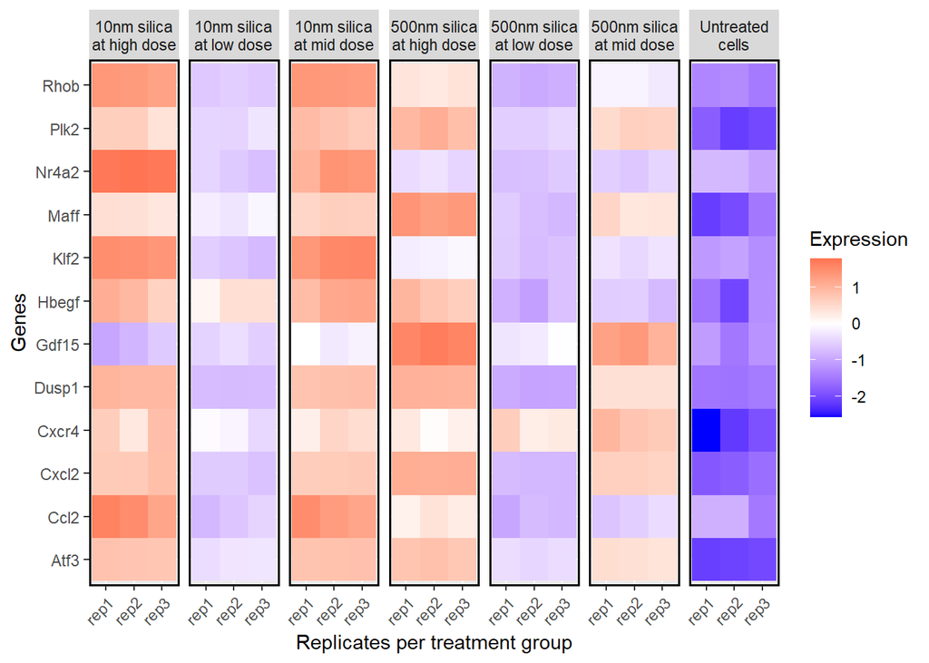

```r
dat.list <- list()
for(gg in goi.all){
  dat.list[[gg]] <- metadata_simplified |>
    mutate(E=scale(dataVoom$E[gg,])) |>
    rownames_to_column("sample") |>
    remove_rownames()
}
(p.vals <- bind_rows(dat.list, .id = "ID") |>
    mutate(
      sample = as.character(sample),

      # extract rep number for x-axis
      sample_label = str_extract(sample, "(?i)rep\\s*\\d+") %>%
        str_replace_all("\\s+", "") %>%
        trimws(),

      # create label WITHOUT rep numbers
      treatment_clean = sample %>%
        str_remove("(?i)rep\\s*\\d+") %>%   # remove "rep1"/"rep 1"
        str_remove(",\\s*$") %>%            # remove comma and spaces
        str_replace_all("_$", "") %>%       # remove trailing underscores
        str_trim()
    ) |>
    ggplot(aes(x = sample_label, y = ID, fill = E)) +
    geom_tile() +
    facet_grid(
      . ~ treatment_clean,
      space = "free",
      scales = "free",
      labeller = labeller(treatment_clean = function(x) str_wrap(x, width = 12))
    ) +
    scale_fill_gradient2(low = "blue", high = "red") +
    labs(x = "Replicates per treatment group", y = "Genes", fill = "Expression") +
    theme(
      plot.title = element_text(hjust = 0.5),
      panel.border = element_rect(color = "black", fill = NA, size = 1),
      axis.text.x = element_text(angle = 45, hjust = 1)
    )
)
```

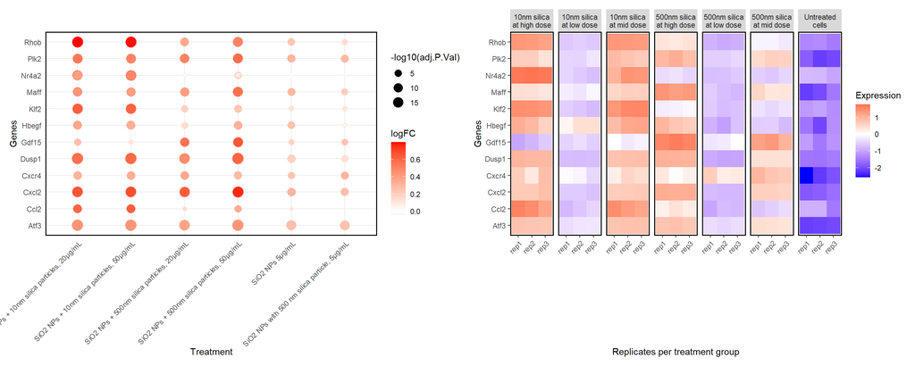

```r
p.coef + p.vals
```

```r
limmaRes %>%
  filter(ID %in% goi.all) %>%
  select(ID, coef, logFC) %>%
  arrange(desc(logFC))
```

```
##       ID                                         coef        logFC
## 1   Rhob    SiO2 NPs + 10nm silica particles, 20µg/mL  0.799493861
## 2   Rhob    SiO2 NPs + 10nm silica particles, 50µg/mL  0.790705206
## 3  Cxcl2   SiO2 NPs + 500nm silica particles, 50µg/mL  0.759828068
## 4  Nr4a2    SiO2 NPs + 10nm silica particles, 50µg/mL  0.705629369
## 5  Cxcl2    SiO2 NPs + 10nm silica particles, 50µg/mL  0.673887504
## 6  Cxcl2    SiO2 NPs + 10nm silica particles, 20µg/mL  0.657701574
## 7  Gdf15   SiO2 NPs + 500nm silica particles, 50µg/mL  0.654052703
## 8  Cxcl2   SiO2 NPs + 500nm silica particles, 20µg/mL  0.634747570
## 9   Ccl2    SiO2 NPs + 10nm silica particles, 50µg/mL  0.631005116
## 10  Klf2    SiO2 NPs + 10nm silica particles, 20µg/mL  0.630577200
## 11 Nr4a2    SiO2 NPs + 10nm silica particles, 20µg/mL  0.628156514
## 12  Klf2    SiO2 NPs + 10nm silica particles, 50µg/mL  0.615555712
## 13 Dusp1   SiO2 NPs + 500nm silica particles, 50µg/mL  0.607513723
## 14  Ccl2    SiO2 NPs + 10nm silica particles, 20µg/mL  0.604552055
```

[output cut: 70 more lines]

**5.6) Perform enrichment analysis. Are the results expected biologically (do you see expected pathways regulated)?**

**`Enrichment analysis for each coefficient`**

```r
fisher_list <- list()
for(coefx in unique(limmaResSig$coef)){

  # What is coefx now?
  message(coefx)

  # Extract genes of interests (GOI) for a given coefficient (see yesterday's example)
  goi <- limmaResSig %>% filter(coef == coefx) %>% pull(ID) |> unique()

  universe <- limmaResSig$ID |> unique()
  universe <- universe[!is.na(universe) & universe != ""]
  MSigDB <- readRDS("MSigDB.rds")
  fisher_tbl <- map_df(names(MSigDB), function(pw) {
    pw_genes <- MSigDB[[pw]]
    sig_genes <- goi
    overlap <- intersect(sig_genes, pw_genes)
    a <- length(overlap)
    b <- length(sig_genes) - a
    c <- length(pw_genes) - a
    d <- length(universe) - (a+b+c)

    ft <- fisher.test(matrix(c(a,b,c,d),2), alternative = "greater")

    tibble(
      pathway = pw,
      pvalue = ft$p.value,
      odds_ratio = as.numeric(ft$estimate),
      DE_in_pathway = a,
      overlapping_genes = paste(overlap, collapse = ",")
    )
  })
  fisher_tbl <- fisher_tbl |> mutate(p_adj = p.adjust(pvalue, "BH"))
  print(head(fisher_tbl))

  # Store results in the list
  fisher_list[[coefx]] <- fisher_tbl
}
```

```
## SiO2 NPs + 10nm silica particles, 20µg/mL
```

```
## # A tibble: 6 × 6
##   pathway                pvalue odds_ratio DE_in_pathway overlapping_genes p_adj
##   <chr>                   <dbl>      <dbl>         <int> <chr>             <dbl>
## 1 HALLMARK_ADIPOGENESIS   1.000      0.501            63 Ubc,Plin2,Angptl…     1
## 2 HALLMARK_ALLOGRAFT_RE…  1.000      0.410            56 Ccl4,Tnf,Ccl2,Gp…     1
## 3 HALLMARK_ANDROGEN_RES…  1.000      0.286            26 Ndrg1,Tnfaip8,Sc…     1
## 4 HALLMARK_ANGIOGENESIS   0.987      0.487            11 Olr1,Vegfa,Nrp1,…     1
## 5 HALLMARK_APICAL_JUNCT…  1          0.175            28 Traf1,Mapk14,Spe…     1
## 6 HALLMARK_APICAL_SURFA…  1.000      0.141             5 Plaur,Gas1,Dcbld…     1
```

```
## SiO2 NPs + 10nm silica particles, 50µg/mL
```

```
## # A tibble: 6 × 6
##   pathway                pvalue odds_ratio DE_in_pathway overlapping_genes p_adj
##   <chr>                   <dbl>      <dbl>         <int> <chr>             <dbl>
## 1 HALLMARK_ADIPOGENESIS   1          0.247            86 Ubc,Plin2,Dnajb9…     1
## 2 HALLMARK_ALLOGRAFT_RE…  1          0.176            72 Ccl4,Tnf,Ccl2,Gp…     1
## 3 HALLMARK_ANDROGEN_RES…  1          0.174            43 Ndrg1,Scd2,Tnfai…     1
## 4 HALLMARK_ANGIOGENESIS   1.000      0.193            13 Olr1,Spp1,Vegfa,…     1
## 5 HALLMARK_APICAL_JUNCT…  1          0.153            64 Pten,Traf1,Ikbkg…     1
## 6 HALLMARK_APICAL_SURFA…  1.000      0.113            11 Plaur,Brca1,Scub…     1
```

```
## SiO2 NPs + 500nm silica particles, 20µg/mL
```

```
## # A tibble: 6 × 6
##   pathway                pvalue odds_ratio DE_in_pathway overlapping_genes p_adj
##   <chr>                   <dbl>      <dbl>         <int> <chr>             <dbl>
## 1 HALLMARK_ADIPOGENESIS   0.999      0.527            22 Ubc,Nabp1,Angptl… 1.000
## 2 HALLMARK_ALLOGRAFT_RE…  0.999      0.542            23 Ccl4,Tnf,Igsf6,G… 1.000
## 3 HALLMARK_ANDROGEN_RES…  0.972      0.631            16 Hmgcs1,Tnfaip8,H… 1.000
## 4 HALLMARK_ANGIOGENESIS   0.832      0.698             5 Vegfa,Lpl,Nrp1,S… 1.000
## 5 HALLMARK_APICAL_JUNCT…  1.000      0.247            11 Traf1,Mapk14,Mvd… 1.000
## 6 HALLMARK_APICAL_SURFA…  0.999      0.205             2 Plaur,Flot2       1.000
```

```
## SiO2 NPs + 500nm silica particles, 50µg/mL
```

```
## # A tibble: 6 × 6
##   pathway                pvalue odds_ratio DE_in_pathway overlapping_genes p_adj
##   <chr>                   <dbl>      <dbl>         <int> <chr>             <dbl>
## 1 HALLMARK_ADIPOGENESIS   1          0.302            72 Ubc,Nabp1,Abca1,…     1
## 2 HALLMARK_ALLOGRAFT_RE…  1          0.279            70 Ccl4,Tnf,St8sia4…     1
## 3 HALLMARK_ANDROGEN_RES…  1.000      0.285            43 Ndrg1,Tnfaip8,Hm…     1
## 4 HALLMARK_ANGIOGENESIS   1.000      0.243            11 Nrp1,Olr1,Itgav,…     1
## 5 HALLMARK_APICAL_JUNCT…  1          0.163            47 Traf1,Mapk14,Ada…     1
## 6 HALLMARK_APICAL_SURFA…  1.000      0.207            12 Adam10,Plaur,Dcb…     1
```

```
## SiO2 NPs 5µg/mL
```

```
## # A tibble: 6 × 6
##   pathway                pvalue odds_ratio DE_in_pathway overlapping_genes p_adj
##   <chr>                   <dbl>      <dbl>         <int> <chr>             <dbl>
## 1 HALLMARK_ADIPOGENESIS   1.000      0.222             3 Ubc,Pim3,Angptl4  1.000
## 2 HALLMARK_ALLOGRAFT_RE…  0.741      0.849            11 Ccl4,Tnf,Irf4,St… 1.000
## 3 HALLMARK_ANDROGEN_RES…  0.804      0.751             6 Ndrg1,Pdlim5,Tnf… 1.000
## 4 HALLMARK_ANGIOGENESIS   0.903      0.426             1 Vegfa             1.000
## 5 HALLMARK_APICAL_JUNCT…  0.999      0.300             4 Lima1,Traf1,Cd27… 1.000
## 6 HALLMARK_APICAL_SURFA…  0.943      0.346             1 Adam10            1.000
```

```
## SiO2 NPs with 500 nm silica particle, 5µg/mL
```

```
## # A tibble: 6 × 6
##   pathway                pvalue odds_ratio DE_in_pathway overlapping_genes p_adj
##   <chr>                   <dbl>      <dbl>         <int> <chr>             <dbl>
## 1 HALLMARK_ADIPOGENESIS   0.866      0.642             4 "Ubc,Pim3,Angptl… 1
## 2 HALLMARK_ALLOGRAFT_RE…  0.171      1.49              9 "Ccl4,Tnf,Cd28,F… 0.853
## 3 HALLMARK_ANDROGEN_RES…  0.533      1.05              4 "Tnfaip8,Hmgcs1,… 1
## 4 HALLMARK_ANGIOGENESIS   1          0                 0 ""                1
## 5 HALLMARK_APICAL_JUNCT…  0.998      0.156             1 "Cd274"           1
## 6 HALLMARK_APICAL_SURFA…  1          0                 0 ""                1
```

**Combining results of enrichment analysis in a table:**

```r
str(fisher_list)
```

```
## List of 6
##  $ SiO2 NPs + 10nm silica particles, 20µg/mL   : tibble [50 × 6] (S3: tbl_df/tbl/data.frame)
##   ..$ pathway          : chr [1:50] "HALLMARK_ADIPOGENESIS" "HALLMARK_ALLOGRAFT_REJECTION" "HALLMARK_ANDROGEN_RESPONSE" "HALLMARK_ANGIOGENESIS" ...
##   ..$ pvalue           : num [1:50] 1 1 1 0.987 1 ...
##   ..$ odds_ratio       : num [1:50] 0.501 0.41 0.286 0.487 0.175 ...
##   ..$ DE_in_pathway    : int [1:50] 63 56 26 11 28 5 66 29 32 25 ...
##   ..$ overlapping_genes: chr [1:50] "Ubc,Plin2,Angptl4,Pim3,Nabp1,Dnajb9,Cdkn2c,Fabp4,Cd151,Abca1,Cd302,Por,Idh1,Ubqln1,Dbt,Slc1a5,Stat5a,Hibch,G3bp"| __truncated__ "Ccl4,Tnf,Ccl2,Gpr65,Igsf6,Il16,Lif,St8sia4,Dyrk3,Csf1,Stat1,Ccr1,Tlr2,Ccl7,Ltb,Il18,Itgb2,Ifnar2,Timp1,Irf4,Jak"| __truncated__ "Nd…
##   ..$ p_adj            : num [1:50] 1 1 1 1 1 1 1 1 1 1 ...
##  $ SiO2 NPs + 10nm silica particles, 50µg/mL   : tibble [50 × 6] (S3: tbl_df/tbl/data.frame)
##   ..$ pathway          : chr [1:50] "HALLMARK_ADIPOGENESIS" "HALLMARK_ALLOGRAFT_REJECTION" "HALLMARK_ANDROGEN_RESPONSE" "HALLMARK_ANGIOGENESIS" ...
##   ..$ pvalue           : num [1:50] 1 1 1 1 1 ...
##   ..$ odds_ratio       : num [1:50] 0.247 0.176 0.174 0.193 0.153 ...
##   ..$ DE_in_pathway    : int [1:50] 86 72 43 13 64 11 81 45 42 49 ...
##   ..$ overlapping_genes: chr [1:50] "Ubc,Plin2,Dnajb9,Pim3,Angptl4,Cdkn2c,Nabp1,Cd302,Hibch,Cd151,Idh1,Abca1,Ubqln1,Cat,Pfkfb3,G3bp2,Cmpk1,Rab34,Dbt"| __truncated__ "Ccl4,Tnf,Ccl2,Gpr65,Lif,Il16,Igsf6,Ccr1,Dyrk3,Tlr2,St8sia4,Csf1,Abce1,Stat1,Jak2,Ccl7,Ltb,Cd28,Il11,Cd47,Il18,I"| __truncated__ "Nd…
##   ..$ p_adj            : num [1:50] 1 1 1 1 1 1 1 1 1 1 ...
##  $ SiO2 NPs + 500nm silica particles, 20µg/mL  : tibble [50 × 6] (S3: tbl_df/tbl/data.frame)
##   ..$ pathway          : chr [1:50] "HALLMARK_ADIPOGENESIS" "HALLMARK_ALLOGRAFT_REJECTION" "HALLMARK_ANDROGEN_RESPONSE" "HALLMARK_ANGIOGENESIS" ...
##   ..$ pvalue           : num [1:50] 0.999 0.999 0.972 0.832 1 ...
##   ..$ odds_ratio       : num [1:50] 0.527 0.542 0.631 0.698 0.247 ...
##   ..$ DE_in_pathway    : int [1:50] 22 23 16 5 11 2 37 12 27 14 ...
##   ..$ overlapping_genes: chr [1:50] "Ubc,Nabp1,Angptl4,Pim3,Abca1,Dnajb9,Fabp4,Cd302,Ccng2,Por,Bcl6,G3bp2,Cd36,Dbt,Lifr,Lpl,Sod1,Cd151,Phldb1,Pdcd4,Sdhc,Tank" "Ccl4,Tnf,Igsf6,Gpr65,Il16,St8sia4,Fcgr2b,Tlr3,Il15,Ifnar2,Cd47,Stat1,Bcl10,Jak2,Cd28,Csf1,Il4ra,Tap1,Icosl,Irf4,Ltb,Ly86,Ctss" "Hmgcs1,Tn…
##   ..$ p_adj            : num [1:50] 1 1 1 1 1 ...
##  $ SiO2 NPs + 500nm silica particles, 50µg/mL  : tibble [50 × 6] (S3: tbl_df/tbl/data.frame)
##   ..$ pathway          : chr [1:50] "HALLMARK_ADIPOGENESIS" "HALLMARK_ALLOGRAFT_REJECTION" "HALLMARK_ANDROGEN_RESPONSE" "HALLMARK_ANGIOGENESIS" ...
##   ..$ pvalue           : num [1:50] 1 1 1 1 1 ...
##   ..$ odds_ratio       : num [1:50] 0.302 0.279 0.285 0.243 0.163 ...
##   ..$ DE_in_pathway    : int [1:50] 72 70 43 11 47 12 70 38 45 47 ...
##   ..$ overlapping_genes: chr [1:50] "Ubc,Nabp1,Abca1,Angptl4,Pim3,Bcl6,Fabp4,Cd302,Dnajb9,G3bp2,Dbt,Sorbs1,Rtn3,Idh1,Por,Lpl,Itsn1,Baz2a,Rreb1,Dram2"| __truncated__ "Ccl4,Tnf,St8sia4,Gpr65,Csf1,Igsf6,Il16,Bcl10,Cd86,Ifnar2,Ccl2,Stat1,Cd47,Tlr3,Fcgr2b,Degs1,Ctss,Jak2,Irf4,Lif,P"| __truncated__ "Nd…
##   ..$ p_adj            : num [1:50] 1 1 1 1 1 1 1 1 1 1 ...
##  $ SiO2 NPs 5µg/mL                             : tibble [50 × 6] (S3: tbl_df/tbl/data.frame)
##   ..$ pathway          : chr [1:50] "HALLMARK_ADIPOGENESIS" "HALLMARK_ALLOGRAFT_REJECTION" "HALLMARK_ANDROGEN_RESPONSE" "HALLMARK_ANGIOGENESIS" ...
##   ..$ pvalue           : num [1:50] 1 0.741 0.804 0.903 0.999 ...
##   ..$ odds_ratio       : num [1:50] 0.222 0.849 0.751 0.426 0.3 ...
##   ..$ DE_in_pathway    : int [1:50] 3 11 6 1 4 1 19 3 8 10 ...
##   ..$ overlapping_genes: chr [1:50] "Ubc,Pim3,Angptl4" "Ccl4,Tnf,Irf4,St8sia4,Gpr65,Il16,Fcgr2b,Ifnar2,Igsf6,Map3k7,Nlrp3" "Ndrg1,Pdlim5,Tnfaip8,Srf,Hpgd,Hmgcs1" "Vegfa" ...
##   ..$ p_adj            : num [1:50] 1 1 1 1 1 ...
##  $ SiO2 NPs with 500 nm silica particle, 5µg/mL: tibble [50 × 6] (S3: tbl_df/tbl/data.frame)
##   ..$ pathway          : chr [1:50] "HALLMARK_ADIPOGENESIS" "HALLMARK_ALLOGRAFT_REJECTION" "HALLMARK_ANDROGEN_RESPONSE" "HALLMARK_ANGIOGENESIS" ...
##   ..$ pvalue           : num [1:50] 0.866 0.171 0.533 1 0.998 ...
##   ..$ odds_ratio       : num [1:50] 0.642 1.488 1.051 0 0.156 ...
##   ..$ DE_in_pathway    : int [1:50] 4 9 4 0 1 0 14 2 7 4 ...
##   ..$ overlapping_genes: chr [1:50] "Ubc,Pim3,Angptl4,Por" "Ccl4,Tnf,Cd28,Fcgr2b,St8sia4,Tlr3,Il16,Igsf6,Gpr65" "Tnfaip8,Hmgcs1,Plpp1,Ncoa4" "" ...
##   ..$ p_adj            : num [1:50] 1 0.853 1 1 1 ...
```

```r
fisher_tbl <- bind_rows(fisher_list, .id = "coef")
head(fisher_tbl)
```

```
## # A tibble: 6 × 7
##   coef           pathway pvalue odds_ratio DE_in_pathway overlapping_genes p_adj
##   <chr>          <chr>    <dbl>      <dbl>         <int> <chr>             <dbl>
## 1 SiO2 NPs + 10… HALLMA…  1.000      0.501            63 Ubc,Plin2,Angptl…     1
## 2 SiO2 NPs + 10… HALLMA…  1.000      0.410            56 Ccl4,Tnf,Ccl2,Gp…     1
## 3 SiO2 NPs + 10… HALLMA…  1.000      0.286            26 Ndrg1,Tnfaip8,Sc…     1
## 4 SiO2 NPs + 10… HALLMA…  0.987      0.487            11 Olr1,Vegfa,Nrp1,…     1
## 5 SiO2 NPs + 10… HALLMA…  1          0.175            28 Traf1,Mapk14,Spe…     1
## 6 SiO2 NPs + 10… HALLMA…  1.000      0.141             5 Plaur,Gas1,Dcbld…     1
```

**Top 10 enriched pathways based on most significant (lowest p-value) per treatment condition)**

```r
top10_pathways <- fisher_tbl %>%
  mutate(
    coef = sub("^SiO2 NPs \\+ |^SiO2 NPs with ", "", coef)   # removing the prefix "stimulus"
  ) %>%
  group_by(coef) %>%
  arrange(p_adj, .by_group = TRUE) %>%
  slice_head(n = 10) %>%
  ungroup()
```

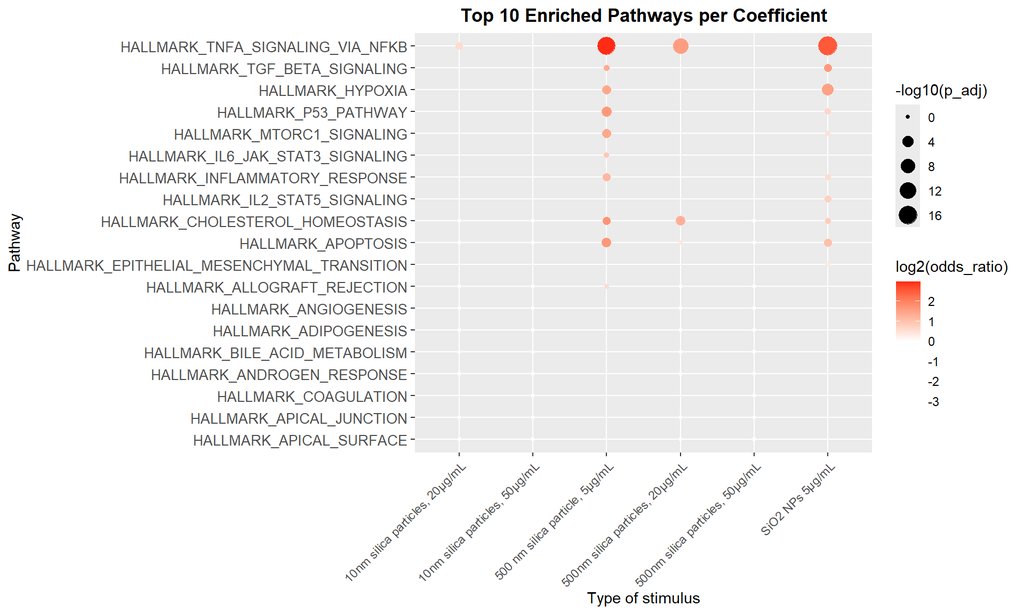

```r
ggplot(top10_pathways, aes(
  x = coef,
  y = reorder(pathway, odds_ratio),
  size = -log10(p_adj),
  color = log2(odds_ratio)
)) +
  geom_point() +
  scale_size_continuous(name = "-log10(p_adj)") +
  scale_color_gradient2(low = "white", high = "red", name = "log2(odds_ratio)") +
  labs(
    x = "Type of stimulus",
    y = "Pathway",
    title = "Top 10 Enriched Pathways per Coefficient"
  ) +
  theme(
    axis.text.y = element_text(size = 10),
    plot.title = element_text(face = "bold", hjust = 0.5),
    axis.text.x = element_text(angle = 45, hjust = 1)
  )
```

**Extracting genes underlying the most proeminant enrichments**

```r
enriched_genes <- top10_pathways |>
  filter(-log10(p_adj) > 4 & log2(odds_ratio) > 2) |>
  pull("overlapping_genes") |>
  str_split(",") |>
  unlist() |>
  unique()

limmaRes.filter <- limmaRes %>%
  mutate(
    coef = sub("^SiO2 NPs \\+ |^SiO2 NPs with ", "", coef),  # removing the prefix "stimulus"
  ) %>%
  filter(ID %in% enriched_genes)
```

Here I also don’t understand how I’m not being able to filter only the top 10. What am I doing wrong? :(

[figure not shown]

```r
limmaRes.filter |> ggplot(aes(
  x = coef,
  y = ID,
  size = -log10(adj.P.Val),
  color = logFC
)) +
  geom_point() +
  scale_size_continuous(name = "-log10(adj.P.Val)") +
  scale_color_gradient2(low = "purple", high = "red", name = "logFC") +
  labs(
    x = "Treatment",
    y = "Gene",
    title = "Top 10 genes with enriched pathways"
  ) +
  theme_minimal(base_size = 12) +
  theme(
    axis.text.y = element_text(size = 10),
    plot.title = element_text(face = "bold", hjust = 0.5),
    axis.text.x = element_text(angle = 45, hjust = 1)
  )
```

**5.7) Discuss 3 significant genes. Plot the data for those genes and plot or report their statistics (log fold change and p-value).**

Getting the top 3 most significant genes (highest logFC):

```r
top3 <- limmaResSig %>% arrange(desc(logFC)) %>%  distinct(ID, .keep_all = TRUE) %>% slice_head(n = 3) %>% pull(ID)
print(top3)
```

```
## [1] "Rhob"  "Cxcl2" "Nr4a2"
```

**`Plotting statistics`**

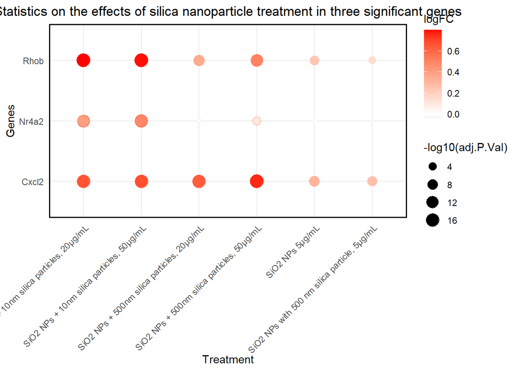

```r
(top3_statistics <- limmaRes %>%
    filter(ID %in% top3) %>%
    ggplot(aes(y=ID, x=str_remove(coef, "treatment"), color=logFC, size=-log10(adj.P.Val))) +
    geom_point() +
    scale_color_gradient2(high="red", low="blue") +
    theme_minimal() +
    labs(
      title = "Statistics on the effects of silica nanoparticle treatment in three significant genes",
      x = "Treatment",
      y = "Genes"
    ) +
    theme(
      plot.title = element_text(hjust = 0.5),        # center the title
      panel.border = element_rect(color = "black",
                                  fill = NA, size = 1),  # black border
      axis.text.x = element_text(angle = 45, hjust = 1)  # diagonal x labels
    ))
```

**`Plotting expression data`**

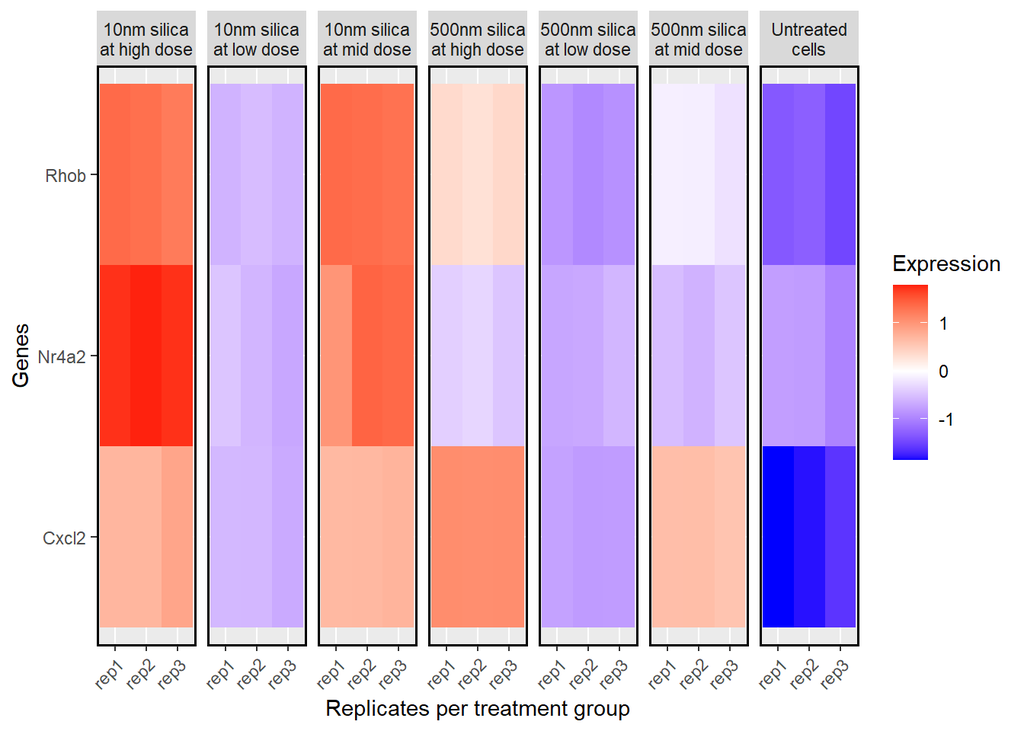

```r
dat.list <- list()
for(gg in top3){
  dat.list[[gg]] <- metadata_simplified |>
    mutate(E=scale(dataVoom$E[gg,])) |>
    rownames_to_column("sample") |>
    remove_rownames()
}
(top3_expression <- bind_rows(dat.list, .id = "ID") |>
    mutate(
      sample = as.character(sample),

      # extract rep number for x-axis
      sample_label = str_extract(sample, "(?i)rep\\s*\\d+") %>%
        str_replace_all("\\s+", "") %>%
        trimws(),

      # create label WITHOUT rep numbers
      treatment_clean = sample %>%
        str_remove("(?i)rep\\s*\\d+") %>%   # remove "rep1"/"rep 1"
        str_remove(",\\s*$") %>%            # remove comma and spaces
        str_replace_all("_$", "") %>%       # remove trailing underscores
        str_trim()
    ) |>
    ggplot(aes(x = sample_label, y = ID, fill = E)) +
    geom_tile() +
    facet_grid(
      . ~ treatment_clean,
      space = "free",
      scales = "free",
      labeller = labeller(treatment_clean = function(x) str_wrap(x, width = 12))
    ) +
    scale_fill_gradient2(low = "blue", high = "red") +
    labs(x = "Replicates per treatment group", y = "Genes", fill = "Expression") +
    theme(
      plot.title = element_text(hjust = 0.5),
      panel.border = element_rect(color = "black", fill = NA, size = 1),
      axis.text.x = element_text(angle = 45, hjust = 1)
    )
)
```

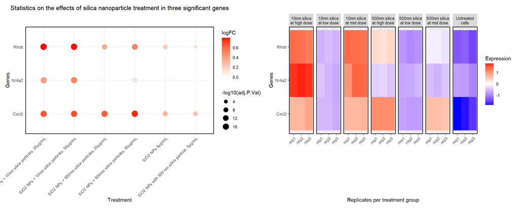

```r
top3_statistics + top3_expression
```

By observing expression data and statistics on log fold changes and P values of **Rhob**, **Nr4a2** and **Cxcl2**, it’s possible to observe that 10nm silica particles cause the most proeminent upregulating effect at high and mid doses.

Indeed, the authors declared that *(size-specific) gene expression changes were identified,* although *the overall biological processes represented by all gene expression changes were nearly identical, irrespective of particle diameter* - honestly I’m not sure what they mean here.

Finally, the high expression of **Rhob** in 10nm treatments is consistent with stress response upon nanoparticle exposure and/or changes in membrane dynamics, e.g. nanoparticle uptake. The moderate basal expression is consistent with the role of Rhob as a rapid-response regulator rather than an important modulator (as it is the case for Nr4a2) - but again, functional experiments would be needed in order to confirm this. Or I would have to read a lot and possibly write a Master Thesis about it, and we ain’t got no time for that at the moment :D